# Risk Factor Analysis

## Outcome Variable

**Outcome Variable:** stunted

## Predictor Variables

**Intervention Variable:** pers_wast

**Adjustment Set:**

unadjusted

## Stratifying Variables

The analysis was stratified on these variable(s):

- agecat
- studyid
- country

## Data Summary

| agecat | studyid | country | pers_wast | stunted | n_cell | n | outcome_variable |
| --- | --- | --- | --- | --- | --- | --- | --- |
| Birth | ki0047075b-MAL-ED | BANGLADESH | 0 | 0 | 180 | 229 | stunted |
| Birth | ki0047075b-MAL-ED | BANGLADESH | 0 | 1 | 40 | 229 | stunted |
| Birth | ki0047075b-MAL-ED | BANGLADESH | 1 | 0 | 7 | 229 | stunted |
| Birth | ki0047075b-MAL-ED | BANGLADESH | 1 | 1 | 2 | 229 | stunted |
| Birth | ki0047075b-MAL-ED | BRAZIL | 0 | 0 | 56 | 65 | stunted |
| Birth | ki0047075b-MAL-ED | BRAZIL | 0 | 1 | 9 | 65 | stunted |
| Birth | ki0047075b-MAL-ED | BRAZIL | 1 | 0 | 0 | 65 | stunted |
| Birth | ki0047075b-MAL-ED | BRAZIL | 1 | 1 | 0 | 65 | stunted |
| Birth | ki0047075b-MAL-ED | INDIA | 0 | 0 | 33 | 45 | stunted |
| Birth | ki0047075b-MAL-ED | INDIA | 0 | 1 | 10 | 45 | stunted |
| Birth | ki0047075b-MAL-ED | INDIA | 1 | 0 | 2 | 45 | stunted |
| Birth | ki0047075b-MAL-ED | INDIA | 1 | 1 | 0 | 45 | stunted |
| Birth | ki0047075b-MAL-ED | NEPAL | 0 | 0 | 24 | 27 | stunted |
| Birth | ki0047075b-MAL-ED | NEPAL | 0 | 1 | 2 | 27 | stunted |
| Birth | ki0047075b-MAL-ED | NEPAL | 1 | 0 | 1 | 27 | stunted |
| Birth | ki0047075b-MAL-ED | NEPAL | 1 | 1 | 0 | 27 | stunted |
| Birth | ki0047075b-MAL-ED | PERU | 0 | 0 | 207 | 233 | stunted |
| Birth | ki0047075b-MAL-ED | PERU | 0 | 1 | 26 | 233 | stunted |
| Birth | ki0047075b-MAL-ED | PERU | 1 | 0 | 0 | 233 | stunted |
| Birth | ki0047075b-MAL-ED | PERU | 1 | 1 | 0 | 233 | stunted |
| Birth | ki0047075b-MAL-ED | SOUTH AFRICA | 0 | 0 | 102 | 113 | stunted |
| Birth | ki0047075b-MAL-ED | SOUTH AFRICA | 0 | 1 | 9 | 113 | stunted |
| Birth | ki0047075b-MAL-ED | SOUTH AFRICA | 1 | 0 | 2 | 113 | stunted |
| Birth | ki0047075b-MAL-ED | SOUTH AFRICA | 1 | 1 | 0 | 113 | stunted |
| Birth | ki0047075b-MAL-ED | TANZANIA, UNITED REPUBLIC OF | 0 | 0 | 101 | 123 | stunted |
| Birth | ki0047075b-MAL-ED | TANZANIA, UNITED REPUBLIC OF | 0 | 1 | 22 | 123 | stunted |
| Birth | ki0047075b-MAL-ED | TANZANIA, UNITED REPUBLIC OF | 1 | 0 | 0 | 123 | stunted |
| Birth | ki0047075b-MAL-ED | TANZANIA, UNITED REPUBLIC OF | 1 | 1 | 0 | 123 | stunted |
| Birth | ki1000108-CMC-V-BCS-2002 | INDIA | 0 | 0 | 68 | 92 | stunted |
| Birth | ki1000108-CMC-V-BCS-2002 | INDIA | 0 | 1 | 12 | 92 | stunted |

[output cut: 170 more lines]

The following strata were considered:

- agecat: 24 months, studyid: ki0047075b-MAL-ED, country: BANGLADESH
- agecat: 24 months, studyid: ki0047075b-MAL-ED, country: BRAZIL
- agecat: 24 months, studyid: ki0047075b-MAL-ED, country: INDIA
- agecat: 24 months, studyid: ki0047075b-MAL-ED, country: NEPAL
- agecat: 24 months, studyid: ki0047075b-MAL-ED, country: PERU
- agecat: 24 months, studyid: ki0047075b-MAL-ED, country: SOUTH AFRICA
- agecat: 24 months, studyid: ki0047075b-MAL-ED, country: TANZANIA, UNITED REPUBLIC OF
- agecat: 24 months, studyid: ki1000108-CMC-V-BCS-2002, country: INDIA
- agecat: 24 months, studyid: ki1000108-IRC, country: INDIA
- agecat: 24 months, studyid: ki1000109-EE, country: PAKISTAN
- agecat: 24 months, studyid: ki1017093b-PROVIDE, country: BANGLADESH
- agecat: 24 months, studyid: ki1066203-TanzaniaChild2, country: TANZANIA, UNITED REPUBLIC OF
- agecat: 24 months, studyid: ki1101329-Keneba, country: GAMBIA
- agecat: 24 months, studyid: ki1113344-GMS-Nepal, country: NEPAL
- agecat: 24 months, studyid: ki1114097-CMIN, country: BANGLADESH
- agecat: 24 months, studyid: ki1114097-CONTENT, country: PERU
- agecat: 6 months, studyid: ki0047075b-MAL-ED, country: BANGLADESH
- agecat: 6 months, studyid: ki0047075b-MAL-ED, country: BRAZIL
- agecat: 6 months, studyid: ki0047075b-MAL-ED, country: INDIA
- agecat: 6 months, studyid: ki0047075b-MAL-ED, country: NEPAL
- agecat: 6 months, studyid: ki0047075b-MAL-ED, country: PERU
- agecat: 6 months, studyid: ki0047075b-MAL-ED, country: SOUTH AFRICA
- agecat: 6 months, studyid: ki0047075b-MAL-ED, country: TANZANIA, UNITED REPUBLIC OF
- agecat: 6 months, studyid: ki1000108-CMC-V-BCS-2002, country: INDIA
- agecat: 6 months, studyid: ki1000108-IRC, country: INDIA
- agecat: 6 months, studyid: ki1000109-EE, country: PAKISTAN
- agecat: 6 months, studyid: ki1000109-ResPak, country: PAKISTAN
- agecat: 6 months, studyid: ki1017093b-PROVIDE, country: BANGLADESH
- agecat: 6 months, studyid: ki1066203-TanzaniaChild2, country: TANZANIA, UNITED REPUBLIC OF
- agecat: 6 months, studyid: ki1101329-Keneba, country: GAMBIA
- agecat: 6 months, studyid: ki1112895-Guatemala BSC, country: GUATEMALA
- agecat: 6 months, studyid: ki1113344-GMS-Nepal, country: NEPAL
- agecat: 6 months, studyid: ki1114097-CMIN, country: BANGLADESH
- agecat: 6 months, studyid: ki1114097-CONTENT, country: PERU
- agecat: Birth, studyid: ki0047075b-MAL-ED, country: BANGLADESH
- agecat: Birth, studyid: ki0047075b-MAL-ED, country: BRAZIL
- agecat: Birth, studyid: ki0047075b-MAL-ED, country: INDIA
- agecat: Birth, studyid: ki0047075b-MAL-ED, country: NEPAL
- agecat: Birth, studyid: ki0047075b-MAL-ED, country: PERU
- agecat: Birth, studyid: ki0047075b-MAL-ED, country: SOUTH AFRICA
- agecat: Birth, studyid: ki0047075b-MAL-ED, country: TANZANIA, UNITED REPUBLIC OF
- agecat: Birth, studyid: ki1000108-CMC-V-BCS-2002, country: INDIA
- agecat: Birth, studyid: ki1000108-IRC, country: INDIA
- agecat: Birth, studyid: ki1000109-EE, country: PAKISTAN
- agecat: Birth, studyid: ki1000109-ResPak, country: PAKISTAN
- agecat: Birth, studyid: ki1017093b-PROVIDE, country: BANGLADESH
- agecat: Birth, studyid: ki1101329-Keneba, country: GAMBIA
- agecat: Birth, studyid: ki1113344-GMS-Nepal, country: NEPAL
- agecat: Birth, studyid: ki1114097-CMIN, country: BANGLADESH
- agecat: Birth, studyid: ki1114097-CONTENT, country: PERU

### Dropped Strata

Some strata were dropped due to rare outcomes:

- agecat: Birth, studyid: ki0047075b-MAL-ED, country: BANGLADESH
- agecat: Birth, studyid: ki0047075b-MAL-ED, country: BRAZIL
- agecat: Birth, studyid: ki0047075b-MAL-ED, country: INDIA
- agecat: Birth, studyid: ki0047075b-MAL-ED, country: NEPAL
- agecat: Birth, studyid: ki0047075b-MAL-ED, country: PERU
- agecat: Birth, studyid: ki0047075b-MAL-ED, country: SOUTH AFRICA
- agecat: Birth, studyid: ki0047075b-MAL-ED, country: TANZANIA, UNITED REPUBLIC OF
- agecat: Birth, studyid: ki1000109-ResPak, country: PAKISTAN
- agecat: Birth, studyid: ki1017093b-PROVIDE, country: BANGLADESH
- agecat: Birth, studyid: ki1101329-Keneba, country: GAMBIA
- agecat: Birth, studyid: ki1114097-CMIN, country: BANGLADESH
- agecat: Birth, studyid: ki1114097-CONTENT, country: PERU
- agecat: 6 months, studyid: ki0047075b-MAL-ED, country: BANGLADESH
- agecat: 6 months, studyid: ki0047075b-MAL-ED, country: BRAZIL
- agecat: 6 months, studyid: ki0047075b-MAL-ED, country: INDIA
- agecat: 6 months, studyid: ki0047075b-MAL-ED, country: NEPAL
- agecat: 6 months, studyid: ki0047075b-MAL-ED, country: PERU
- agecat: 6 months, studyid: ki0047075b-MAL-ED, country: SOUTH AFRICA
- agecat: 6 months, studyid: ki0047075b-MAL-ED, country: TANZANIA, UNITED REPUBLIC OF
- agecat: 6 months, studyid: ki1000109-ResPak, country: PAKISTAN
- agecat: 6 months, studyid: ki1066203-TanzaniaChild2, country: TANZANIA, UNITED REPUBLIC OF
- agecat: 6 months, studyid: ki1112895-Guatemala BSC, country: GUATEMALA
- agecat: 6 months, studyid: ki1114097-CMIN, country: BANGLADESH
- agecat: 6 months, studyid: ki1114097-CONTENT, country: PERU
- agecat: 24 months, studyid: ki0047075b-MAL-ED, country: BANGLADESH
- agecat: 24 months, studyid: ki0047075b-MAL-ED, country: BRAZIL
- agecat: 24 months, studyid: ki0047075b-MAL-ED, country: INDIA
- agecat: 24 months, studyid: ki0047075b-MAL-ED, country: NEPAL
- agecat: 24 months, studyid: ki0047075b-MAL-ED, country: PERU
- agecat: 24 months, studyid: ki0047075b-MAL-ED, country: SOUTH AFRICA
- agecat: 24 months, studyid: ki0047075b-MAL-ED, country: TANZANIA, UNITED REPUBLIC OF
- agecat: 24 months, studyid: ki1000109-EE, country: PAKISTAN
- agecat: 24 months, studyid: ki1017093b-PROVIDE, country: BANGLADESH
- agecat: 24 months, studyid: ki1066203-TanzaniaChild2, country: TANZANIA, UNITED REPUBLIC OF
- agecat: 24 months, studyid: ki1114097-CMIN, country: BANGLADESH
- agecat: 24 months, studyid: ki1114097-CONTENT, country: PERU

## Methods Detail

We’re interested in the causal parameters $E[Y_a]$ for all values of $a \in \mathcal{A}$. These parameters represent the mean outcome if, possibly contrary to fact, we intervened to set all units to have $A=a$. Under the randomization and positivity assumptions, these are identified by the statistical parameters $\psi_a=E_W[E_{Y|A,W}(Y|A=a,W)]$. In addition, we’re interested in the mean of $Y$, $E[Y]$ under no intervention (the observed mean). We will estimate these parameters by using SuperLearner to fit the relevant likelihood factors – $E_{Y|A,W}(Y|A=a,W)$ and $p(A=a|W)$, and then updating our likelihood fit using a joint TMLE.

For unadjusted analyses ($W=\{\}$), initial likelihoods were estimated using Lrnr_glm to estimate the simple $E(Y|A)$ and Lrnr_mean to estimate $p(A)$. For adjusted analyses, a small library containing Lrnr_glmnet, Lrnr_xgboost, and Lrnr_mean was used.

Having estimated these parameters, we will then use the delta method to estimate relative risks and attributable risks relative to a prespecified baseline level of $A$.

# Results Detail

## Results Plots

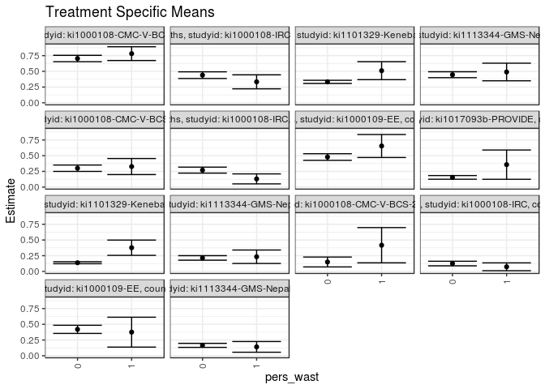

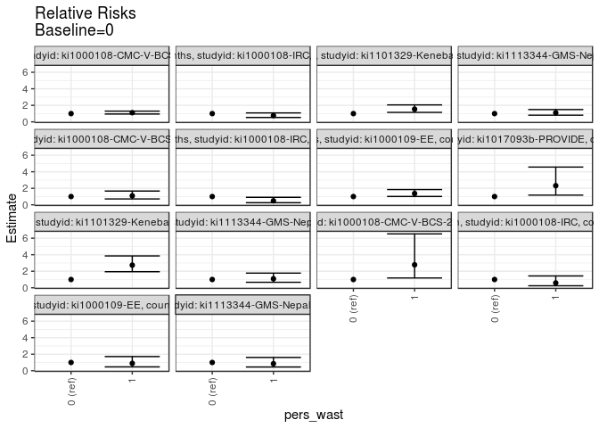

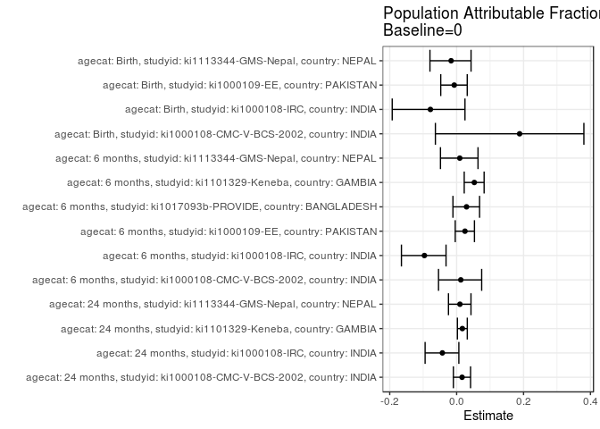

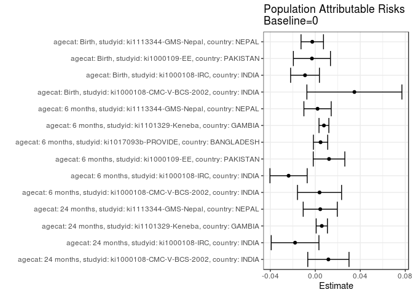

## Results Table

### Parameter: TSM

| agecat | studyid | country | intervention_level | baseline_level | estimate | ci_lower | ci_upper |
| --- | --- | --- | --- | --- | --- | --- | --- |
| Birth | ki1000108-CMC-V-BCS-2002 | INDIA | 0 | NA | 0.1500000 | 0.0713260 | 0.2286740 |
| Birth | ki1000108-CMC-V-BCS-2002 | INDIA | 1 | NA | 0.4166667 | 0.1361986 | 0.6971348 |
| Birth | ki1000108-IRC | INDIA | 0 | NA | 0.1253918 | 0.0890040 | 0.1617797 |
| Birth | ki1000108-IRC | INDIA | 1 | NA | 0.0735294 | 0.0114136 | 0.1356452 |
| Birth | ki1000109-EE | PAKISTAN | 0 | NA | 0.4196429 | 0.3548811 | 0.4844046 |
| Birth | ki1000109-EE | PAKISTAN | 1 | NA | 0.3750000 | 0.1372884 | 0.6127116 |
| Birth | ki1113344-GMS-Nepal | NEPAL | 0 | NA | 0.1650672 | 0.1331623 | 0.1969720 |
| Birth | ki1113344-GMS-Nepal | NEPAL | 1 | NA | 0.1406250 | 0.0553833 | 0.2258667 |
| 6 months | ki1000108-CMC-V-BCS-2002 | INDIA | 0 | NA | 0.3003195 | 0.2494669 | 0.3511721 |
| 6 months | ki1000108-CMC-V-BCS-2002 | INDIA | 1 | NA | 0.3269231 | 0.1992506 | 0.4545956 |
| 6 months | ki1000108-IRC | INDIA | 0 | NA | 0.2700297 | 0.2225698 | 0.3174896 |
| 6 months | ki1000108-IRC | INDIA | 1 | NA | 0.1304348 | 0.0508726 | 0.2099970 |
| 6 months | ki1000109-EE | PAKISTAN | 0 | NA | 0.4783862 | 0.4257566 | 0.5310158 |
| 6 months | ki1000109-EE | PAKISTAN | 1 | NA | 0.6538462 | 0.4707342 | 0.8369581 |
| 6 months | ki1017093b-PROVIDE | BANGLADESH | 0 | NA | 0.1542373 | 0.1250152 | 0.1834594 |
| 6 months | ki1017093b-PROVIDE | BANGLADESH | 1 | NA | 0.3571429 | 0.1242409 | 0.5900448 |
| 6 months | ki1101329-Keneba | GAMBIA | 0 | NA | 0.1377996 | 0.1220287 | 0.1535704 |
| 6 months | ki1101329-Keneba | GAMBIA | 1 | NA | 0.3770492 | 0.2553960 | 0.4987024 |
| 6 months | ki1113344-GMS-Nepal | NEPAL | 0 | NA | 0.2144289 | 0.1783859 | 0.2504719 |
| 6 months | ki1113344-GMS-Nepal | NEPAL | 1 | NA | 0.2333333 | 0.1262177 | 0.3404490 |
| 24 months | ki1000108-CMC-V-BCS-2002 | INDIA | 0 | NA | 0.7041801 | 0.6533855 | 0.7549747 |
| 24 months | ki1000108-CMC-V-BCS-2002 | INDIA | 1 | NA | 0.7818182 | 0.6725175 | 0.8911189 |
| 24 months | ki1000108-IRC | INDIA | 0 | NA | 0.4395280 | 0.3866285 | 0.4924275 |
| 24 months | ki1000108-IRC | INDIA | 1 | NA | 0.3333333 | 0.2219680 | 0.4446987 |
| 24 months | ki1101329-Keneba | GAMBIA | 0 | NA | 0.3326165 | 0.3078838 | 0.3573492 |
| 24 months | ki1101329-Keneba | GAMBIA | 1 | NA | 0.5106383 | 0.3676760 | 0.6536006 |
| 24 months | ki1113344-GMS-Nepal | NEPAL | 0 | NA | 0.4465116 | 0.3994748 | 0.4935485 |
| 24 months | ki1113344-GMS-Nepal | NEPAL | 1 | NA | 0.4897959 | 0.3496813 | 0.6299105 |

### Parameter: E(Y)

| agecat | studyid | country | intervention_level | baseline_level | estimate | ci_lower | ci_upper |
| --- | --- | --- | --- | --- | --- | --- | --- |
| Birth | ki1000108-CMC-V-BCS-2002 | INDIA | NA | NA | 0.1847826 | 0.1050392 | 0.2645260 |
| Birth | ki1000108-IRC | INDIA | NA | NA | 0.1162791 | 0.0843002 | 0.1482579 |
| Birth | ki1000109-EE | PAKISTAN | NA | NA | 0.4166667 | 0.3541635 | 0.4791698 |
| Birth | ki1113344-GMS-Nepal | NEPAL | NA | NA | 0.1623932 | 0.1324811 | 0.1923052 |
| 6 months | ki1000108-CMC-V-BCS-2002 | INDIA | NA | NA | 0.3041096 | 0.2568508 | 0.3513684 |
| 6 months | ki1000108-IRC | INDIA | NA | NA | 0.2463054 | 0.2043435 | 0.2882673 |
| 6 months | ki1000109-EE | PAKISTAN | NA | NA | 0.4906166 | 0.4398159 | 0.5414174 |
| 6 months | ki1017093b-PROVIDE | BANGLADESH | NA | NA | 0.1589404 | 0.1297581 | 0.1881227 |
| 6 months | ki1101329-Keneba | GAMBIA | NA | NA | 0.1454929 | 0.1296218 | 0.1613640 |
| 6 months | ki1113344-GMS-Nepal | NEPAL | NA | NA | 0.2164580 | 0.1822877 | 0.2506283 |
| 24 months | ki1000108-CMC-V-BCS-2002 | INDIA | NA | NA | 0.7158470 | 0.6695782 | 0.7621158 |
| 24 months | ki1000108-IRC | INDIA | NA | NA | 0.4215686 | 0.3735941 | 0.4695432 |
| 24 months | ki1101329-Keneba | GAMBIA | NA | NA | 0.3384189 | 0.3139882 | 0.3628495 |
| 24 months | ki1113344-GMS-Nepal | NEPAL | NA | NA | 0.4509395 | 0.4063324 | 0.4955465 |

### Parameter: RR

| agecat | studyid | country | intervention_level | baseline_level | estimate | ci_lower | ci_upper |
| --- | --- | --- | --- | --- | --- | --- | --- |
| Birth | ki1000108-CMC-V-BCS-2002 | INDIA | 0 | 0 | 1.0000000 | 1.0000000 | 1.0000000 |
| Birth | ki1000108-CMC-V-BCS-2002 | INDIA | 1 | 0 | 2.7777778 | 1.1833052 | 6.5207600 |
| Birth | ki1000108-IRC | INDIA | 0 | 0 | 1.0000000 | 1.0000000 | 1.0000000 |
| Birth | ki1000108-IRC | INDIA | 1 | 0 | 0.5863971 | 0.2400313 | 1.4325693 |
| Birth | ki1000109-EE | PAKISTAN | 0 | 0 | 1.0000000 | 1.0000000 | 1.0000000 |
| Birth | ki1000109-EE | PAKISTAN | 1 | 0 | 0.8936170 | 0.4653847 | 1.7158953 |
| Birth | ki1113344-GMS-Nepal | NEPAL | 0 | 0 | 1.0000000 | 1.0000000 | 1.0000000 |
| Birth | ki1113344-GMS-Nepal | NEPAL | 1 | 0 | 0.8519259 | 0.4509093 | 1.6095869 |
| 6 months | ki1000108-CMC-V-BCS-2002 | INDIA | 0 | 0 | 1.0000000 | 1.0000000 | 1.0000000 |
| 6 months | ki1000108-CMC-V-BCS-2002 | INDIA | 1 | 0 | 1.0885843 | 0.7112161 | 1.6661825 |
| 6 months | ki1000108-IRC | INDIA | 0 | 0 | 1.0000000 | 1.0000000 | 1.0000000 |
| 6 months | ki1000108-IRC | INDIA | 1 | 0 | 0.4830387 | 0.2560322 | 0.9113165 |
| 6 months | ki1000109-EE | PAKISTAN | 0 | 0 | 1.0000000 | 1.0000000 | 1.0000000 |
| 6 months | ki1000109-EE | PAKISTAN | 1 | 0 | 1.3667748 | 1.0116334 | 1.8465911 |
| 6 months | ki1017093b-PROVIDE | BANGLADESH | 0 | 0 | 1.0000000 | 1.0000000 | 1.0000000 |
| 6 months | ki1017093b-PROVIDE | BANGLADESH | 1 | 0 | 2.3155416 | 1.1741604 | 4.5664398 |
| 6 months | ki1101329-Keneba | GAMBIA | 0 | 0 | 1.0000000 | 1.0000000 | 1.0000000 |
| 6 months | ki1101329-Keneba | GAMBIA | 1 | 0 | 2.7362146 | 1.9429997 | 3.8532535 |
| 6 months | ki1113344-GMS-Nepal | NEPAL | 0 | 0 | 1.0000000 | 1.0000000 | 1.0000000 |
| 6 months | ki1113344-GMS-Nepal | NEPAL | 1 | 0 | 1.0881620 | 0.6673888 | 1.7742229 |
| 24 months | ki1000108-CMC-V-BCS-2002 | INDIA | 0 | 0 | 1.0000000 | 1.0000000 | 1.0000000 |
| 24 months | ki1000108-CMC-V-BCS-2002 | INDIA | 1 | 0 | 1.1102532 | 0.9486387 | 1.2994011 |
| 24 months | ki1000108-IRC | INDIA | 0 | 0 | 1.0000000 | 1.0000000 | 1.0000000 |
| 24 months | ki1000108-IRC | INDIA | 1 | 0 | 0.7583893 | 0.5317021 | 1.0817228 |
| 24 months | ki1101329-Keneba | GAMBIA | 0 | 0 | 1.0000000 | 1.0000000 | 1.0000000 |
| 24 months | ki1101329-Keneba | GAMBIA | 1 | 0 | 1.5352164 | 1.1491210 | 2.0510369 |
| 24 months | ki1113344-GMS-Nepal | NEPAL | 0 | 0 | 1.0000000 | 1.0000000 | 1.0000000 |
| 24 months | ki1113344-GMS-Nepal | NEPAL | 1 | 0 | 1.0969388 | 0.8087030 | 1.4879068 |

### Parameter: PAR

| agecat | studyid | country | intervention_level | baseline_level | estimate | ci_lower | ci_upper |
| --- | --- | --- | --- | --- | --- | --- | --- |
| Birth | ki1000108-CMC-V-BCS-2002 | INDIA | 0 | NA | 0.0347826 | -0.0074558 | 0.0770210 |
| Birth | ki1000108-IRC | INDIA | 0 | NA | -0.0091128 | -0.0219144 | 0.0036888 |
| Birth | ki1000109-EE | PAKISTAN | 0 | NA | -0.0029762 | -0.0194618 | 0.0135094 |
| Birth | ki1113344-GMS-Nepal | NEPAL | 0 | NA | -0.0026740 | -0.0126506 | 0.0073026 |
| 6 months | ki1000108-CMC-V-BCS-2002 | INDIA | 0 | NA | 0.0037901 | -0.0158119 | 0.0233921 |
| 6 months | ki1000108-IRC | INDIA | 0 | NA | -0.0237243 | -0.0402762 | -0.0071723 |
| 6 months | ki1000109-EE | PAKISTAN | 0 | NA | 0.0122305 | -0.0018048 | 0.0262657 |
| 6 months | ki1017093b-PROVIDE | BANGLADESH | 0 | NA | 0.0047031 | -0.0016510 | 0.0110572 |
| 6 months | ki1101329-Keneba | GAMBIA | 0 | NA | 0.0076933 | 0.0033150 | 0.0120716 |
| 6 months | ki1113344-GMS-Nepal | NEPAL | 0 | NA | 0.0020291 | -0.0101112 | 0.0141695 |
| 24 months | ki1000108-CMC-V-BCS-2002 | INDIA | 0 | NA | 0.0116669 | -0.0066673 | 0.0300012 |
| 24 months | ki1000108-IRC | INDIA | 0 | NA | -0.0179594 | -0.0391657 | 0.0032469 |
| 24 months | ki1101329-Keneba | GAMBIA | 0 | NA | 0.0058024 | 0.0007998 | 0.0108050 |
| 24 months | ki1113344-GMS-Nepal | NEPAL | 0 | NA | 0.0044278 | -0.0107371 | 0.0195928 |

### Parameter: PAF

| agecat | studyid | country | intervention_level | baseline_level | estimate | ci_lower | ci_upper |
| --- | --- | --- | --- | --- | --- | --- | --- |
| Birth | ki1000108-CMC-V-BCS-2002 | INDIA | 0 | NA | 0.1882353 | -0.0635084 | 0.3803886 |
| Birth | ki1000108-IRC | INDIA | 0 | NA | -0.0783699 | -0.1925958 | 0.0249155 |
| Birth | ki1000109-EE | PAKISTAN | 0 | NA | -0.0071429 | -0.0475024 | 0.0316616 |
| Birth | ki1113344-GMS-Nepal | NEPAL | 0 | NA | -0.0164663 | -0.0797475 | 0.0431062 |
| 6 months | ki1000108-CMC-V-BCS-2002 | INDIA | 0 | NA | 0.0124629 | -0.0541398 | 0.0748576 |
| 6 months | ki1000108-IRC | INDIA | 0 | NA | -0.0963205 | -0.1650175 | -0.0316743 |
| 6 months | ki1000109-EE | PAKISTAN | 0 | NA | 0.0249287 | -0.0042076 | 0.0532197 |
| 6 months | ki1017093b-PROVIDE | BANGLADESH | 0 | NA | 0.0295904 | -0.0110256 | 0.0685747 |
| 6 months | ki1101329-Keneba | GAMBIA | 0 | NA | 0.0528776 | 0.0226907 | 0.0821322 |
| 6 months | ki1113344-GMS-Nepal | NEPAL | 0 | NA | 0.0093741 | -0.0483210 | 0.0638940 |
| 24 months | ki1000108-CMC-V-BCS-2002 | INDIA | 0 | NA | 0.0162981 | -0.0097380 | 0.0416628 |
| 24 months | ki1000108-IRC | INDIA | 0 | NA | -0.0426014 | -0.0942651 | 0.0066232 |
| 24 months | ki1101329-Keneba | GAMBIA | 0 | NA | 0.0171455 | 0.0022512 | 0.0318175 |
| 24 months | ki1113344-GMS-Nepal | NEPAL | 0 | NA | 0.0098191 | -0.0243973 | 0.0428927 |